# Technology and Social Change

Lecture 2: Technology and Markets

Bogdan G. Popescu

bgpopescu@tec.mx

Tecnológico de Monterrey

## Puzzle

### The Productivity-Conflict Paradox

Across history, technological breakthroughs raised productivity and wealth.

Yet they simultaneously generated:

- Mass displacement and immiseration
- Political upheaval and labor unrest
- New forms of social vulnerability

**Central Puzzle:** Why does technology that raises aggregate wealth so often produce social dislocation and conflict?

## Introduction

### The Analytical Challenge

How does technology reshape social and economic relations?

We need an analytical framework that can:

1. Explain how technology alters market organization
2. Identify when innovation produces harm vs. benefit
3. Account for recurring patterns of institutional response
4. Link micro-level economic shifts to macro-level outcomes

## Introduction

### Learning Objectives

By the end of this lecture, you will be able to:

1. Use Polanyi’s embeddedness theory to analyze technology
2. Identify fictitious commodification in historical and modern cases
3. Trace the double movement linking markets and protection
4. Compare how different tech eras generate similar responses

## Introduction

### Lecture Roadmap

1. **Conceptual Framework** — Polanyi’s analytical model
2. **Core Mechanisms** — Embeddedness, commodification, double movement
3. **Historical Case** — The Enclosure Movement
4. **Contemporary Case** — Social media platforms
5. **Competing Views & Modern Relevance** — Alternative frameworks and policy

# Conceptual Framework

## Conceptual Framework

### Karl Polanyi: An Analytical Model

Karl Polanyi (1886–1964) developed a theory of market-society relations.

His framework in *The Great Transformation* (1944) provides:

- A typology of economic organization
- A theory of commodification and its limits
- A dynamic model of societal response

This is not historical description but a **general theory of technological change**.

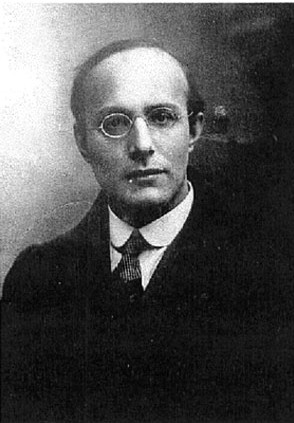

Karl Polanyi, c. 1918. Source: Wikimedia Commons (public domain).

## Conceptual Framework

### Polanyi’s Core Thesis

**Important**

**Thesis:** Organizing society around self-regulating markets is a utopian project that would destroy the human and natural substance of society.

**Implication for technology:** Technological change becomes destructive when it enables commodification of non-commodities.

## Conceptual Framework

### The Embeddedness Spectrum

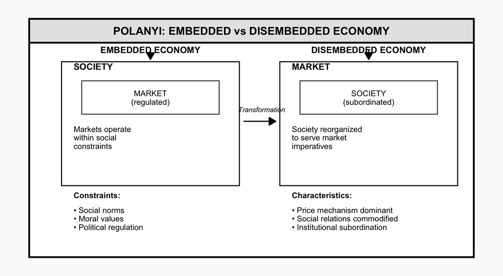

## Conceptual Framework

### So What?

Polanyi gives us a lens: technology doesn’t just create wealth.

It can **disembed** markets from social constraints.

**Next:** What specific mechanisms drive this process?

# Core Mechanisms

## Core Mechanisms

### Mechanism 1: Embeddedness and Disembedding

**Definition:** An economy is *embedded* when economic transactions are subordinate to social relations, norms, and political decisions.

**Disembedding** occurs when:

1. Market logic escapes social constraints
2. Price mechanisms supplant reciprocity
3. Economic imperatives override social obligations

**Key Insight:** Technology does not cause disembedding directly — it creates *conditions of possibility* that actors exploit.

## Core Mechanisms

### How Disembedding Works

```
%%{init: {"theme": "base", "flowchart": {"useMaxWidth": true, "nodeSpacing": 40, "rankSpacing": 50}, "themeVariables": {"fontSize": "18px", "primaryColor": "#e2e8f0", "primaryBorderColor": "#334155", "primaryTextColor": "#1e293b", "lineColor": "#64748b"}, "width": 1150, "height": 650}}%%
flowchart LR
  A["<b>Technological Change</b>"] --> B["New productive<br/>possibilities"]
  B --> C["Capital<br/>interests"]
  B --> D["State actors<br/>seeking revenue"]
  B --> E["Ideological<br/>entrepreneurs"]
  C --> F["<b>Pressure to<br/>Commodify</b>"]
  D --> F
  E --> F
  F --> G["<b>Disembedded<br/>Market Relations</b>"]
```

## Core Mechanisms

### Mechanism 2: Fictitious Commodification

**Definition:** A *fictitious commodity* is something that functions in market exchange but was not produced for sale.

Polanyi identified three foundational fictitious commodities:

Polanyi’s three fictitious commodities. Source: Polanyi (1944).

| Fictitious Commodity | Actual Nature | Harm from Commodification |
| --- | --- | --- |
| **Labor** | Human life | Exploitation, precarity |
| **Land** | Nature/territory | Environmental destruction |
| **Money** | Social convention | Financial instability |

## Core Mechanisms

### The Commodification Paradox

**Warning**

**Paradox:** Markets require labor, land, and money to function as commodities. But treating them as true commodities destroys the foundations markets depend on.

- Labor exhausted → no workers
- Land degraded → no resources
- Money destabilized → no exchange medium

## Core Mechanisms

### Mechanism 3: The Double Movement

**Definition:** The *double movement* describes the dialectical relationship between market expansion and social protection.

**First Movement:** Extension of market relations into non-market domains

**Second Movement:** Societal counter-mobilization to protect against harms

This is not anti-progress but a **self-protective response** inherent to market societies.

## Core Mechanisms

### The Double Movement Dynamic

```
%%{init: {"theme": "base", "flowchart": {"useMaxWidth": true, "nodeSpacing": 40, "rankSpacing": 50}, "themeVariables": {"fontSize": "18px", "primaryColor": "#e2e8f0", "primaryBorderColor": "#334155", "primaryTextColor": "#1e293b", "lineColor": "#64748b"}, "width": 1150, "height": 650}}%%
flowchart LR
  A["<b>First Movement</b><br/>Commodification<br/>Deregulation<br/>Tech disruption"] --> B["<b>Social Harm</b><br/>accumulates"]
  B --> C["<b>Second Movement</b><br/>Labor laws<br/>Social insurance<br/>Environmental regulation"]
  C --> D["<b>Institutional<br/>Response</b>"]
  D -->|"Cycle continues"| A
```

## Core Mechanisms

### Complete Polanyian Causal Chain

**Important**

**Causal Chain:**

Tech Change → Market Expansion → Fictitious Commodification → Social Harm → Political Mobilization → Counter-Movement → New Equilibrium

This sequence provides a **predictive framework** for any technological transition.

## Class Exercise 1

### Identifying the Mechanism

**Prompt:** Think of a technology you use daily (e.g., ride-sharing, food delivery, streaming). Using Polanyi’s three mechanisms, identify:

1. What is being **disembedded** from social norms?
2. What **fictitious commodity** is being created?
3. Is there a **counter-movement** forming?

*Discuss with a partner for 5 minutes.*

## Core Mechanisms

### So What?

Three mechanisms — embeddedness, fictitious commodification, and the double movement — form a unified causal model.

**Next:** Let’s test this model against a historical case.

# Historical Case: The Enclosure Movement

## Historical Case

### Case Overview

- **Period:** 1750s–1850s (Parliamentary Enclosure, England)
- **Technology:** Crop rotation, selective breeding, drainage
- **Institutional Change:** Privatization of common lands
- **Outcome:** Mass displacement, proletarianization

## Historical Case

### Pre-Enclosure: Embedded Land Relations

Before enclosure, land relations were characterized by:

- **Common rights:** Peasants grazed, gathered wood, fished
- **Reciprocal obligations:** Lords protected; peasants labored
- **Non-market allocation:** Access based on custom, not purchase

Land was embedded in a **moral economy** of mutual obligation.

## Historical Case

### The Open Field System

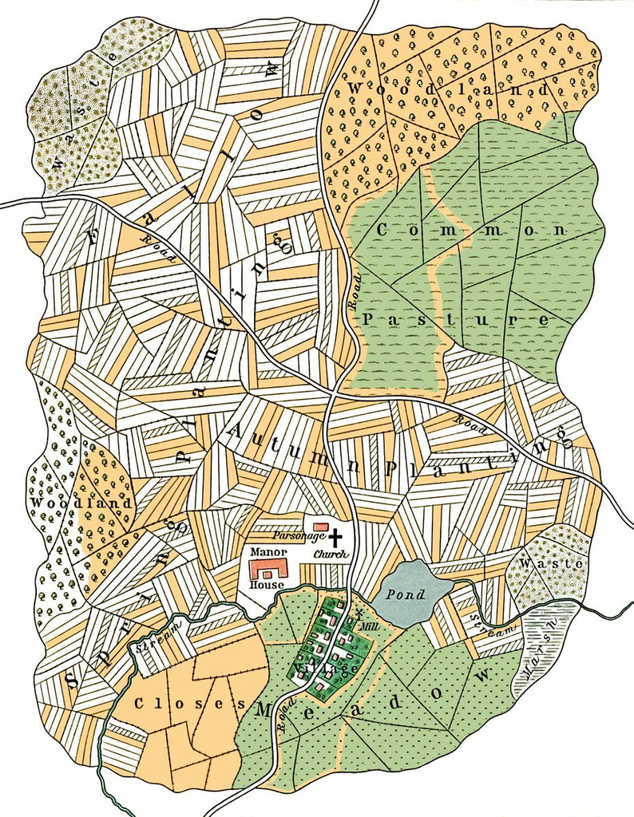

Plan of a medieval English manor showing the open field system: arable land divided into narrow strips among households, with shared common pasture, meadow, and woodland. Source: Shepherd, *Historical Atlas* (1923). Public domain.

## Historical Case

### The Enclosure Process

**First Movement (Market Expansion):**

1. Agricultural tech increased potential productivity
2. Landlords sought gains through consolidated holdings
3. Parliamentary acts authorized privatization of commons
4. Land became alienable property — a commodity

**Land is a fictitious commodity** because it was not produced for sale, its supply cannot respond to price signals, and it embodies community and ecology.

## Historical Case

### Enclosure as Disembedding

```
%%{init: {"theme": "base", "flowchart": {"useMaxWidth": true, "nodeSpacing": 50, "rankSpacing": 60}, "themeVariables": {"fontSize": "18px", "primaryColor": "#e2e8f0", "primaryBorderColor": "#334155", "primaryTextColor": "#1e293b", "lineColor": "#64748b"}, "width": 1150, "height": 650}}%%
flowchart LR
  subgraph Before ["BEFORE: Embedded"]
    A["Common Lands<br/>Shared access<br/>Customary rights"] --> B["Peasant Security<br/>Independent subsistence<br/>Community ties"]
  end

  subgraph After ["AFTER: Disembedded"]
    C["Private Property<br/>Exclusive title<br/>Profit-oriented"] --> D["Proletarianization<br/>Wage-dependent<br/>Market vulnerable"]
  end

  Before -->|"Enclosure<br/>Acts"| After

  %% Fix subgraph header color
  style Before fill:#f9fafb,stroke:#334155,stroke-width:1px
  style After fill:#f9fafb,stroke:#334155,stroke-width:1px
```

## Historical Case

### Parliamentary Enclosure Acts Over Time

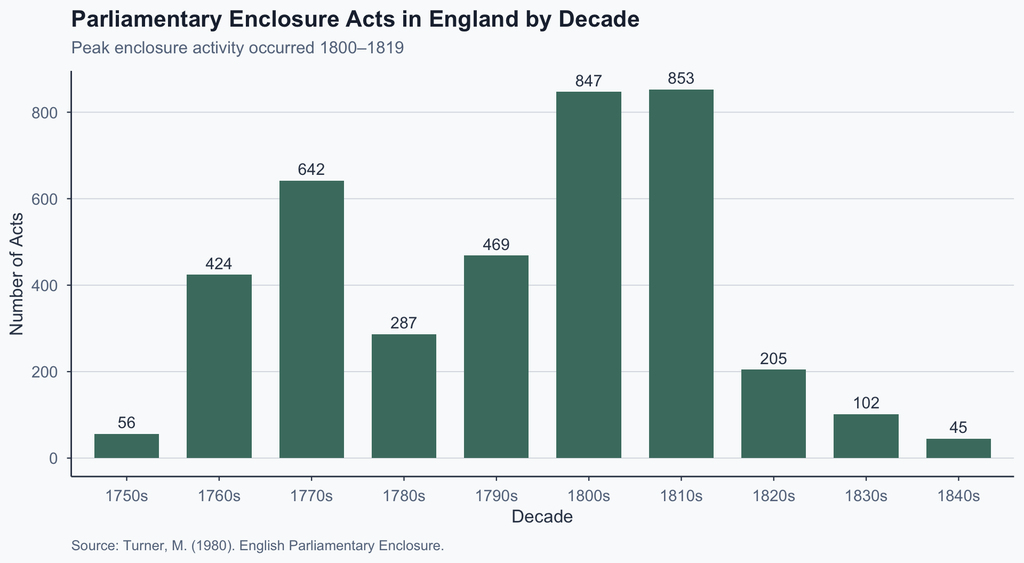

## Historical Case

### The Second Movement: Social Protection

Institutional responses to enclosure harms. Source: Polanyi (1944).

| Institution | Function | Era |
| --- | --- | --- |
| Poor Laws | Subsistence guarantee | 1601, reformed 1834 |
| Factory Acts | Labor protection | 1833 onwards |
| Trade Unions | Collective bargaining | 19th century |
| Welfare State | Comprehensive protection | 20th century |

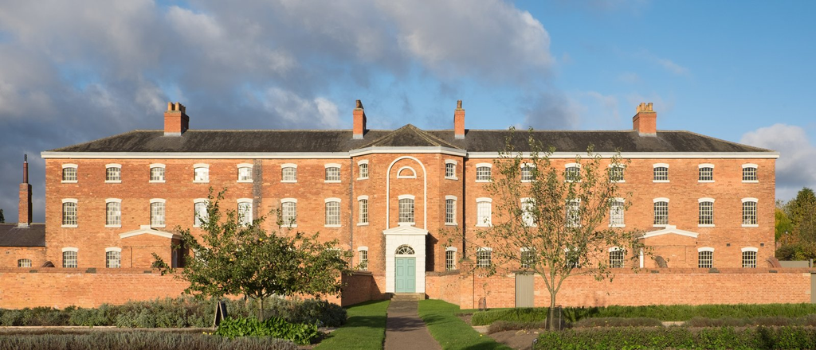

The Southwell Workhouse, Nottinghamshire — a surviving example of Poor Law institutions built to house those displaced by enclosure. Source: Wikimedia Commons.

These represent the **counter-movement** against market expansion.

## Class Exercise 2

### Applying the Framework to Enclosure

**Prompt:** A landlord in 1790s England argues: “Enclosure is simply more efficient — it increases food output for everyone.” Using Polanyi’s framework, construct a counter-argument that acknowledges the efficiency gain but identifies what the landlord’s argument misses.

*Discuss with a partner for 5 minutes.*

## Historical Case

### So What?

Enclosure confirms Polanyi’s model: technology enabled commodification of land, which displaced millions and triggered protective institutions.

**Next:** Do we see the same pattern with digital technology?

# Contemporary Case: Social Media Platforms

## Contemporary Case

### Digital Commodification

Social media platforms represent a new domain of Polanyian dynamics.

**First Movement — market expansion into:**

- Attention (commodified as advertising inventory)
- Social relations (commodified as network data)
- Personal identity (commodified as behavioral profiles)

## Contemporary Case

### Key Harms Identified

- Mental health deterioration (especially adolescents)
- Misinformation propagation
- Privacy erosion
- Democratic manipulation

## Contemporary Case

### Adolescent Mental Health and Social Media

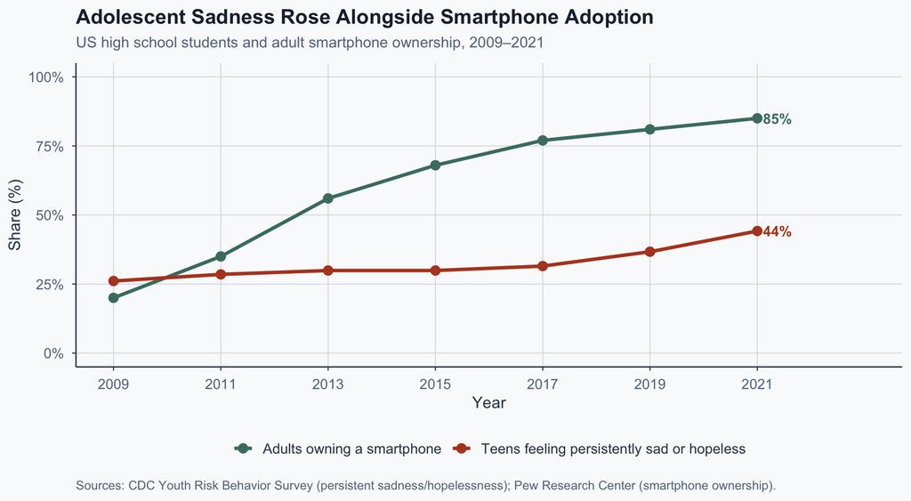

## Case Evidence: Australia’s Social Media Ban

[video not shown]

Source: https://www.youtube.com/watch?v=MkDAXsF4oXA

1. What is Australia’s new social media law for children?  
2. Why does Reddit describe the new law as “arbitrary”?  
3. What happened to Tilly Roseworn?  
4. What is one reason the ban may not fully work?

## Case Evidence: Australia’s Social Media Ban

1. Who should be mainly responsible for protecting teenagers online — governments, companies, parents, or the teenagers themselves? Why?
2. Do you think banning under-16s will actually make teenagers safer, or will it just change where and how they go online?
3. What might young people lose if they are removed from social media until 16, and are those losses worth the protection?

## Contemporary Case

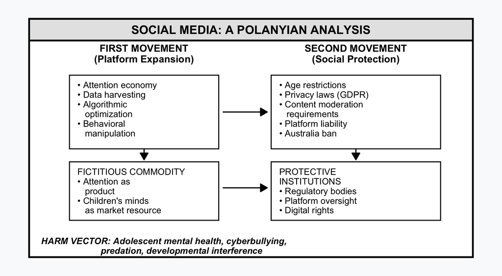

## Contemporary Case

### Comparative Analysis: Enclosure vs. Social Media

Structural parallels across two centuries. Source: Author’s illustration.

| Dimension | Enclosure (18th–19th c.) | Social Media (21st c.) |
| --- | --- | --- |
| **Technology** | Agricultural improvements | Digital platforms |
| **Fictitious commodity** | Land (nature) | Attention (cognition) |
| **Disembedding** | Parliamentary acts | Platform business models |
| **Social harm** | Displacement, poverty | Mental health, manipulation |
| **Counter-movement** | Poor Laws, unions | Age bans, privacy regulation |

## Contemporary Case

### So What?

The same Polanyian pattern — technology → commodification → harm → response — recurs across centuries with different content but identical structure.

**Next:** Are there alternative explanations? Why prefer Polanyi?

# Competing Interpretations

## Competing Interpretations

### Neoclassical Economics

- Market expansion represents efficiency gains
- Harms are “externalities” correctable via property rights
- No inherent tension between markets and society

**Critique:** Cannot explain the systematic recurrence of protective movements across eras and countries.

## Competing Interpretations

### Marxist and Schumpeterian Views

**Karl Marx:**

- Enclosure as “primitive accumulation”
- Class conflict drives institutional change
- **Convergence:** Both identify commodification as harm source
- **Divergence:** Polanyi sees protection as genuine, not just class compromise

**Joseph Schumpeter:**

- “Creative destruction” — old industries fall, new ones rise
- **Polanyian Critique:** Underestimates institutional preconditions; ignores non-market harms

## Competing Interpretations

### Why Polanyi Remains Essential

Polanyi’s framework uniquely explains:

1. Why harm is **systematic**, not incidental
2. Why protection is **endogenous** to market societies
3. Why technology–market interaction needs **institutional mediation**

His model predicts that AI, biotech, and future technologies will generate analogous dynamics.

## Competing Interpretations

### So What?

No rival framework explains both the recurrence of harm and the predictability of protective responses as well as Polanyi’s double movement.

**Next:** How does this framework apply to today’s policy debates?

# Modern Relevance

## Modern Relevance

### Contemporary Applications

Polanyian dynamics in emerging technology domains. Source: Author’s illustration.

| Domain | First Movement | Fictitious Commodity | Counter-Movement |
| --- | --- | --- | --- |
| **AI** | Labor disruption | Human labor | UBI proposals |
| **Gig Economy** | Platform labor | Worker security | Classification laws |
| **Crypto** | Monetary decentral. | Money/trust | Regulatory frameworks |
| **Genetic Data** | Health data markets | Biological identity | Genetic privacy laws |

## Modern Relevance

### Gig Economy Growth

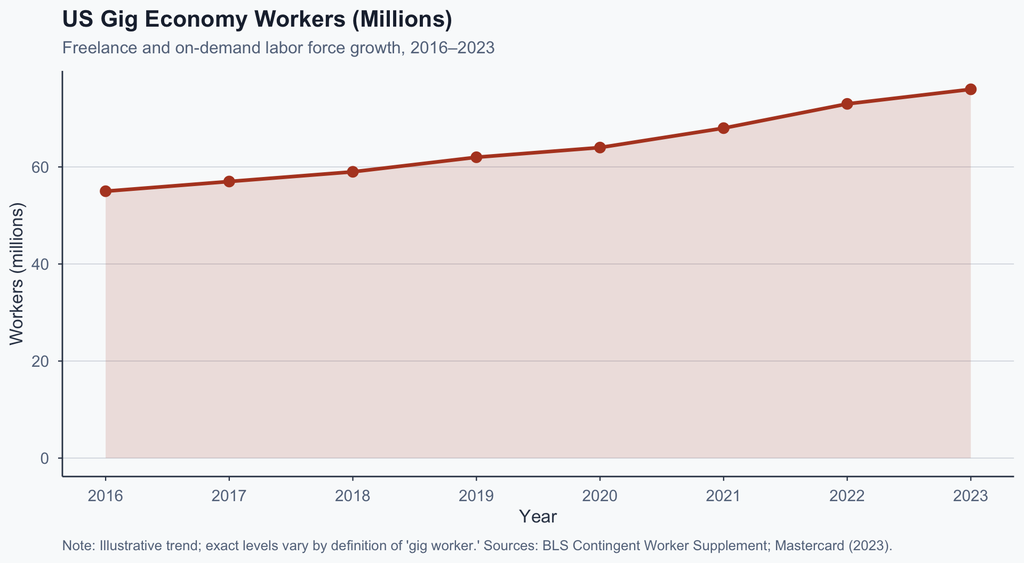

## Modern Relevance

### Policy Implications

Polanyian analysis suggests:

1. **Anticipate harm:** Tech change will commodify new domains
2. **Expect resistance:** Counter-movements are predictable
3. **Design institutions:** Proactive regulation beats reactive crisis
4. **Reject false choices:** “Progress vs. protection” is a false dichotomy

# Key Takeaways

## Key Takeaways

### Analytical Toolkit

For analyzing any technological transition:

1. Identify the **disembedding mechanism**
2. Locate the **fictitious commodity**
3. Trace the **harm vector**
4. Anticipate the **counter-movement**

## Key Takeaways

### Three Eras, One Pattern

Recurrent Polanyian dynamics across technological eras. Source: Author’s illustration.

| Era | Technology | Fictitious Commodity | Counter-Movement |
| --- | --- | --- | --- |
| Agricultural | Enclosure | Land | Poor Laws |
| Industrial | Factory system | Labor | Labor rights |
| Digital | Platforms | Attention | Privacy/safety regulation |
| Emerging | AI | Cognition/identity | ? |

## Key Takeaways

### The Polanyian Cycle

```
%%{init: {"theme": "base", "flowchart": {"useMaxWidth": true, "nodeSpacing": 50, "rankSpacing": 60}, "themeVariables": {"fontSize": "20px", "primaryColor": "#e2e8f0", "primaryBorderColor": "#334155", "primaryTextColor": "#1e293b", "lineColor": "#64748b"}, "width": 1150, "height": 650}}%%
flowchart LR
  A["<b>New Technology</b>"] --> B["<b>Market Expansion</b><br/>Commodification of<br/>non-commodities"]
  B --> C["<b>Social Harm</b><br/>Displacement, precarity,<br/>vulnerability"]
  C --> D["<b>Counter-Movement</b><br/>Regulation, unions,<br/>welfare institutions"]
  D -->|"New equilibrium<br/>until next disruption"| A
```

## Conclusion

**Core Insight:**

Technology does not autonomously produce social outcomes.

The relationship between technology and society is **institutionally mediated**.

Polanyi provides the analytical tools to understand this mediation — across centuries and across technologies.

## Bibliography

Dale, G. (2010). *Karl Polanyi: The limits of the market*. Polity Press.

Granovetter, M. (1985). Economic action and social structure: The problem of embeddedness. *American Journal of Sociology*, *91*(3), 481–510.

Haidt, J. (2024). *The anxious generation: How the great rewiring of childhood is causing an epidemic of mental illness*. Penguin Press.

Polanyi, K. (1944). *The great transformation: The political and economic origins of our time*. Farrar & Rinehart.

Polanyi, K. (1957). The economy as instituted process. In K. Polanyi, C. Arensberg, & H. Pearson (Eds.), *Trade and market in the early empires* (pp. 243–270). Free Press.

Turner, M. (1980). *English parliamentary enclosure: Its historical geography and economic history*. Dawson.